# Body performance

### Goal :

The primary objective of this project is to emphasize the significance of body performance in enhancing physical health and promoting exercise awareness among individuals. This will be accomplished by analyzing and extracting valuable insights from body performance datasets, monitoring the progression of human age, and subsequently improving the overall awareness of its importance.

#### Classification gaol :-

we want to predict performance outcomes (class attribute) based on the other attributes.

### Data Source :

It from Kaggle website , The link( https://www.kaggle.com/datasets/kukuroo3/body-performance-data) show the source data.

### General Information about Body performance dataset :

Table 1 : Data dictionary showing description of all Attributes

| name | description | data type | possible value |
| --- | --- | --- | --- |
| Age | The person’s age in years | numerical | 21-64 |
| Gender | The person’s gender | binary | F,M |
| Height_cm | The person’s Height in cm | numerical | 125-194 |
| weight_kg | The person’s weight in Kg | numerical | 26.3-138 |
| body fat_% | the amount of essential fat . | numerical | 3%-78.4% |
| diastolic | measures pressure the blood vessels when the heart is at rest | numerical | 0-156 |
| systolic | measures pressure in the arteries when the heart beats in minutes | numerical | 0-201 |
| gripForce | fingers flexibility tests | numerical | 0-70.5 |
| sit and bend forward_cm | measures flexibility in sitting and bending forward in centimeters. | numerical | -25-213 |
| sit-ups counts_cm | measures the strength and endurance of the abdominals and hip-flexor muscles in centimeter. | numerical | 0-80 |
| broad jump_cm | It is a method of measuring how far a person can jump from a standing position to a landing position. | numerical | 0-303 |

### Importing the dataset:

```r
##dataset<- read.csv("bodyPerformance.csv")
dataset<-bodyPerformance
View(dataset)
str(dataset)
```

```
'data.frame':   13393 obs. of  12 variables:
 $ age                    : num  27 25 31 32 28 36 42 33 54 28 ...
 $ gender                 : chr  "M" "M" "M" "M" ...
 $ height_cm              : num  172 165 180 174 174 ...
 $ weight_kg              : num  75.2 55.8 78 71.1 67.7 ...
 $ body.fat_.             : num  21.3 15.7 20.1 18.4 17.1 22 32.2 36.9 27.6 14.4 ...
 $ diastolic              : num  80 77 92 76 70 64 72 84 85 81 ...
 $ systolic               : num  130 126 152 147 127 119 135 137 165 156 ...
 $ gripForce              : num  54.9 36.4 44.8 41.4 43.5 23.8 22.7 45.9 40.4 57.9 ...
 $ sit.and.bend.forward_cm: num  18.4 16.3 12 15.2 27.1 21 0.8 12.3 18.6 12.1 ...
 $ sit.ups.counts         : num  60 53 49 53 45 27 18 42 34 55 ...
 $ broad.jump_cm          : num  217 229 181 219 217 153 146 234 148 213 ...
 $ class                  : chr  "C" "A" "C" "B" ...
```

### performance dataset before preprocessing:

```r
print(dataset)
```

| age | gender | height_cm | weight_kg | body.fat_. | diastolic | systolic | gripForce | sit.and.bend.forward_cm | sit.ups.counts | broad.jump_cm | class |
| --- | --- | --- | --- | --- | --- | --- | --- | --- | --- | --- | --- |
| 27 | M | 172.3 | 75.24 | 21.30000 | 80 | 130 | 54.90 | 18.4 | 60 | 217 | C |
| 25 | M | 165.0 | 55.80 | 15.70000 | 77 | 126 | 36.40 | 16.3 | 53 | 229 | A |
| 31 | M | 179.6 | 78.00 | 20.10000 | 92 | 152 | 44.80 | 12.0 | 49 | 181 | C |
| 32 | M | 174.5 | 71.10 | 18.40000 | 76 | 147 | 41.40 | 15.2 | 53 | 219 | B |
| 28 | M | 173.8 | 67.70 | 17.10000 | 70 | 127 | 43.50 | 27.1 | 45 | 217 | B |
| 36 | F | 165.4 | 55.40 | 22.00000 | 64 | 119 | 23.80 | 21.0 | 27 | 153 | B |
| 42 | F | 164.5 | 63.70 | 32.20000 | 72 | 135 | 22.70 | 0.8 | 18 | 146 | D |
| 33 | M | 174.9 | 77.20 | 36.90000 | 84 | 137 | 45.90 | 12.3 | 42 | 234 | B |
| 54 | M | 166.8 | 67.50 | 27.60000 | 85 | 165 | 40.40 | 18.6 | 34 | 148 | C |
| 28 | M | 185.0 | 84.60 | 14.40000 | 81 | 156 | 57.90 | 12.1 | 55 | 213 | B |

[output cut: 990 more lines]

```r
#Number of rows
nrow(dataset)
```

```
[1] 13393
```

```r
#Number of column
ncol(dataset)
```

```
[1] 12
```

### Understanding the dataset using graph representations:

#### Scatter plot of height and weight:-

Observation:

This scatter plot helps us determine whether height and weight are correlated to each other or not. The plot shows a strong positive correlation between the two attributes, indicating a proportional relationship.

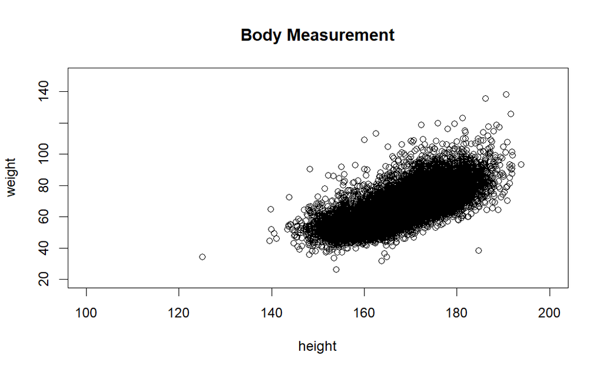

```r
dataset<-bodyPerformance
plot(dataset$height_cm, dataset$weight_kg, main = "Body Measurement",
     xlab = "height", ylab = "weight",
     xlim = c(100,200), ylim = c(20,150))
```

#### Histogram of body fat :-

Observation:

he histogram represents the frequency distribution of body fat values. We observe that the majority of values lie within the range of 10-30. However, the histogram also reveals the presence of outliers in the dataset .

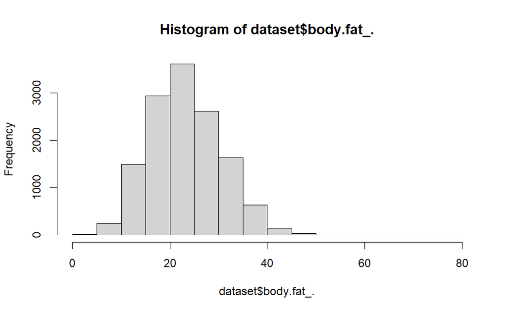

#### Scatter plot for age and diastoic :-

Observation :

This scatter plot helps us determine the correlation between Age and diastolic. The plot shows no correlation between the two attributes, indicating no proportional relationship

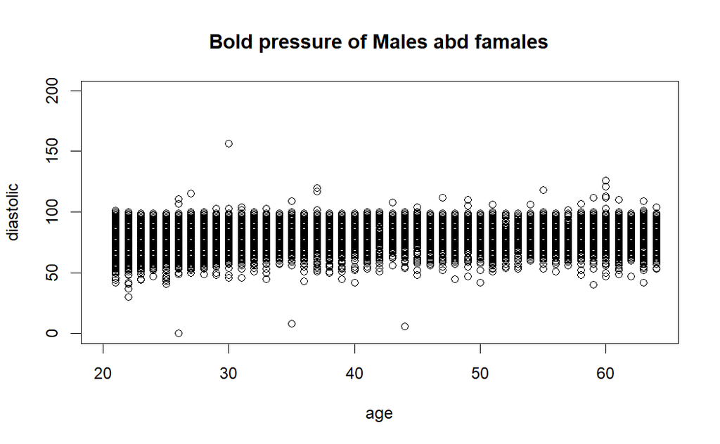

```r
plot(dataset$age, dataset$diastolic, main = "Bold pressure of Males abd famales",
     xlab = "age", ylab = "diastolic",
     xlim = c(20,64), ylim = c(0,200))
```

#### Scatter plot for Gender and class :

first we endcode the gender F to be 0 and M to 1 ,and then encode class A=1 (best),B=2 ,C=3,D=4 then we use the plot to determine the relationship between gender and class attributes , we notice that the female have higher performance then male

```r
 #encoding Class:
#dtaset<- bodyPerformance
dataset$class = factor(dataset$class,levels =
c("A","B", "C","D"), labels = c(1, 2, 3,4))
```

```r
 #encoding Gender:
dataset$gender = factor(dataset$gender,levels =
                         c("F","M"), labels = c(0,1))
```

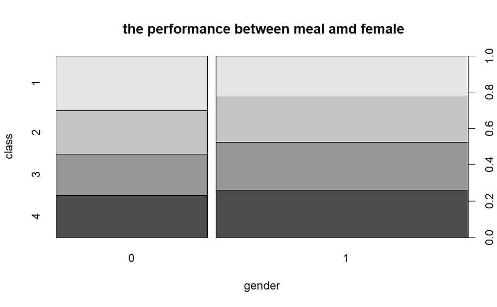

```r
plot(dataset$gender, dataset$class, main = " the performance between meal amd female",
     xlab = "gender", ylab = "class",
     xlim = c(0,1), ylim = c(0,4))
```

```r
NA
```

### Statistical Measures:

```r
sum(duplicated(dataset))
```

```
[1] 1
```

```r
 summary(dataset$age)
```

```
   Min. 1st Qu.  Median    Mean 3rd Qu.    Max.
  21.00   25.00   32.00   36.78   48.00   64.00
```

```r
summary(dataset$height_cm)
```

```
   Min. 1st Qu.  Median    Mean 3rd Qu.    Max.
  125.0   162.4   169.2   168.6   174.8   193.8
```

```r
 summary(dataset$weight_kg)
```

```
   Min. 1st Qu.  Median    Mean 3rd Qu.    Max.
  26.30   58.20   67.40   67.45   75.30  138.10
```

```r
 summary(dataset$body.fat_.)
```

```
   Min. 1st Qu.  Median    Mean 3rd Qu.    Max.
   3.00   18.00   22.80   23.24   28.00   78.40
```

```r
 summary(dataset$diastolic)
```

```
   Min. 1st Qu.  Median    Mean 3rd Qu.    Max.
    0.0    71.0    79.0    78.8    86.0   156.2
```

```r
 summary(dataset$systolic)
```

```
   Min. 1st Qu.  Median    Mean 3rd Qu.    Max.
    0.0   120.0   130.0   130.2   141.0   201.0
```

```r
 summary(dataset$gripForce)
```

```
   Min. 1st Qu.  Median    Mean 3rd Qu.    Max.
   0.00   27.50   37.90   36.96   45.20   70.50
```

```r
 summary(dataset$sit.and.bend.forward_cm)
```

```
   Min. 1st Qu.  Median    Mean 3rd Qu.    Max.
 -25.00   10.90   16.20   15.21   20.70  213.00
```

```r
summary(dataset$sit.ups.counts)
```

```
   Min. 1st Qu.  Median    Mean 3rd Qu.    Max.
   0.00   30.00   41.00   39.77   50.00   80.00
```

```r
 summary(dataset$broad.jump_cm)
```

```
   Min. 1st Qu.  Median    Mean 3rd Qu.    Max.
    0.0   162.0   193.0   190.1   221.0   303.0
```

## Data Preprocessing:

### Check duplicated rows:

We check if there are any duplicated rows to decrease dataset volume. Hence enhancing data quality which leads to better model performance and speed.

```r
sum(duplicated(dataset))
```

```
[1] 1
```

we found 1 row that’s duplicate that need to be deleted.

```r
#Remove duplicated rows
dataset <- dataset[!duplicated (dataset), ]
```

```r
#Remove duplicated rows
dataset <- dataset[!duplicated (dataset), ]
```

```r
#To make sure that the deletion was successful
sum(duplicated(dataset))
```

```
[1] 0
```

### Check nulls value:

Null values can cause issues when performing data analysis or building machine learning models, as they can lead to inaccurate results or errors, where we found then 0 null in our dataset. So, no need to delete any.

```r
#to find the total null values in the dataset
sum(is.na(dataset))
```

[output not shown]

## Detect Outlier and Remove them:

We checked our dataset to see if there were any outlier values, and we found a couple. Statistical studies and modeling can be significantly impacted by the presence of outliers. Outliers can skew results and impair the validity and reliability of inferences made from the research since they are data points that differ dramatically from the majority of the data. Therefore, in order to prevent them from harming our outcomes, we must erase them before we begin our task.

An outlier detection approach was used on the dataset to solve this problem. The detection approach used makes use of the Outliers package’s Outlier() function. This method revealed the outliers among the data points.

```r
#install outliers package:
 library(outliers)
```

#### boxplot to detect outliers:

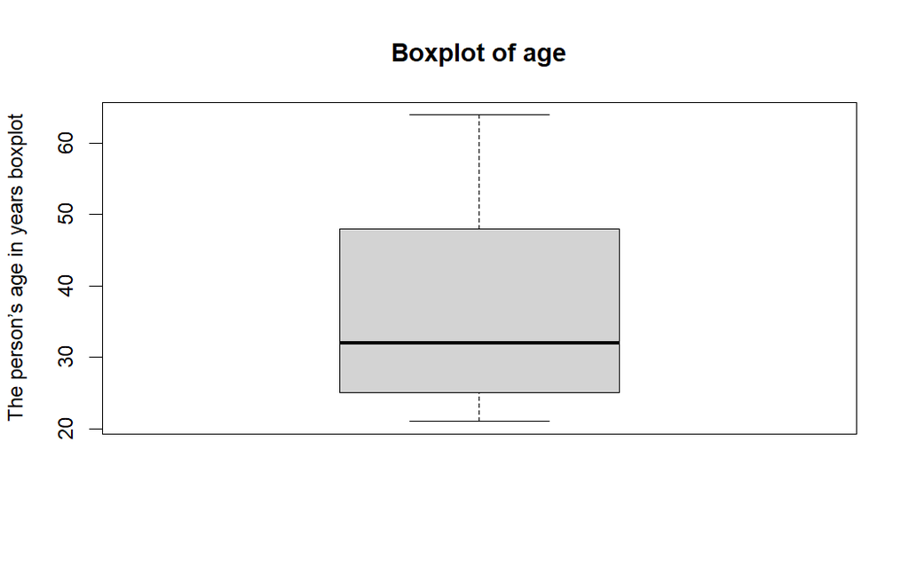

```r
# age boxplot :
boxplot(dataset$age ,
        ylab= "The person’s age in years boxplot",
        main= "Boxplot of age")
```

The summary and box plot values for The person’s height in cm indicate a dataset ranging from 125.0 to 193.8. the median at 169.2, and the mean is 168.6. Comparing the mean and median, we observe that they are relatively close in value. Also, there is some outliers that we will handle it by deleting them in preprocessing steps.

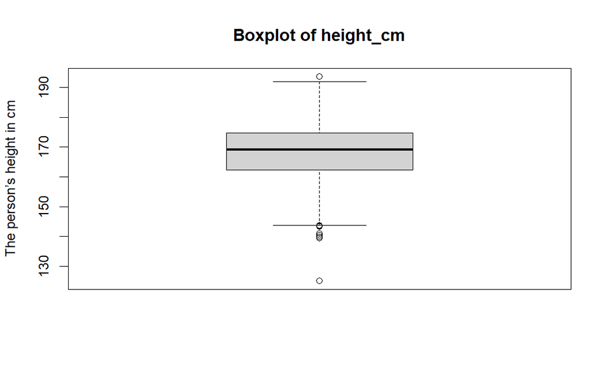

```r
#Hight boxplot :
boxplot(dataset$height_cm ,
        ylab= "The person’s height in cm",
        main= "Boxplot of height_cm")
```

The summary and box plot values for The person’s weight in Kg indicate a dataset ranging from 26.30 to 138.10. The mean weight is 67.45. Comparing the mean and median, we observe that they are relatively close in value, and that due also the maximum outliers.

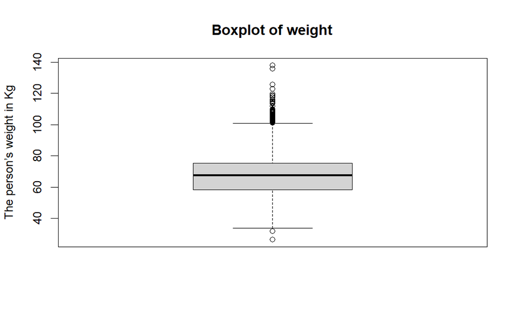

```r
#Weight boxplot;
boxplot(dataset$weight_kg ,
        ylab= "The person’s weight in Kg",
        main= "Boxplot of weight")
```

The boxplot of the person’s body fat (the amount of essential fat .) shows how the values in the dataset have been evenly distributed around the median value of 22.80, and, there some outliers that we will handle them.

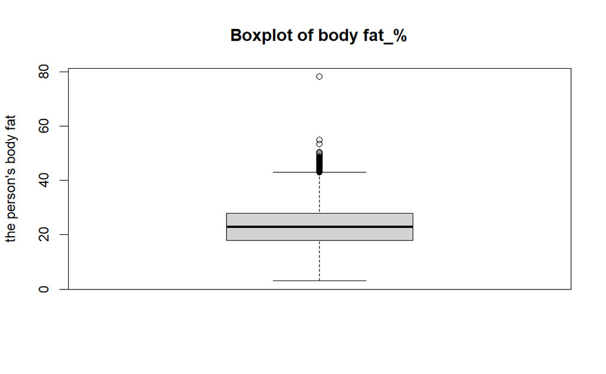

```r
#body fat boxplot :
boxplot(dataset$body.fat_.,
        ylab= "the person's body fat" ,
        main= "Boxplot of body fat_%")
```

```r
NA
NA
```

The boxplot of the person’s diastolic (measures pressure the blood vessels when the heart is at rest) shows how the values in the dataset have been evenly distributed around the median value of 79.0, and, there some outliers that we will handle them

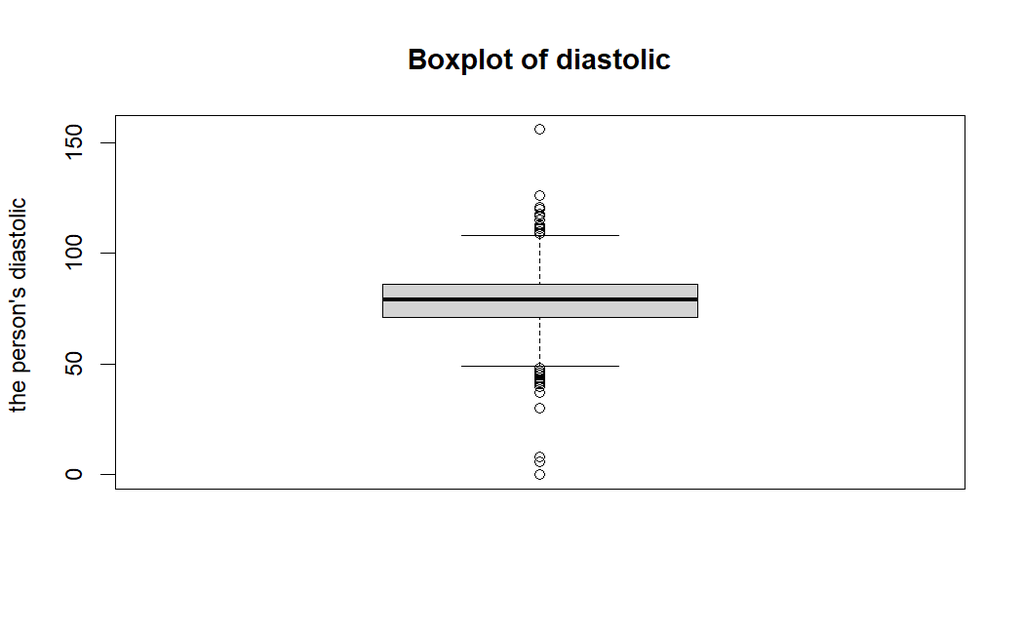

```r
#diastolic box plot :
boxplot(dataset$diastolic,
        ylab= "the person's diastolic ",
        main= "Boxplot of diastolic")
```

The boxplot of the person’s systolic (measures pressure in the arteries when the heart beats in minutes) shows how the values in the dataset have been evenly distributed around the median value of 130.0, and, there some outliers that we will handle them

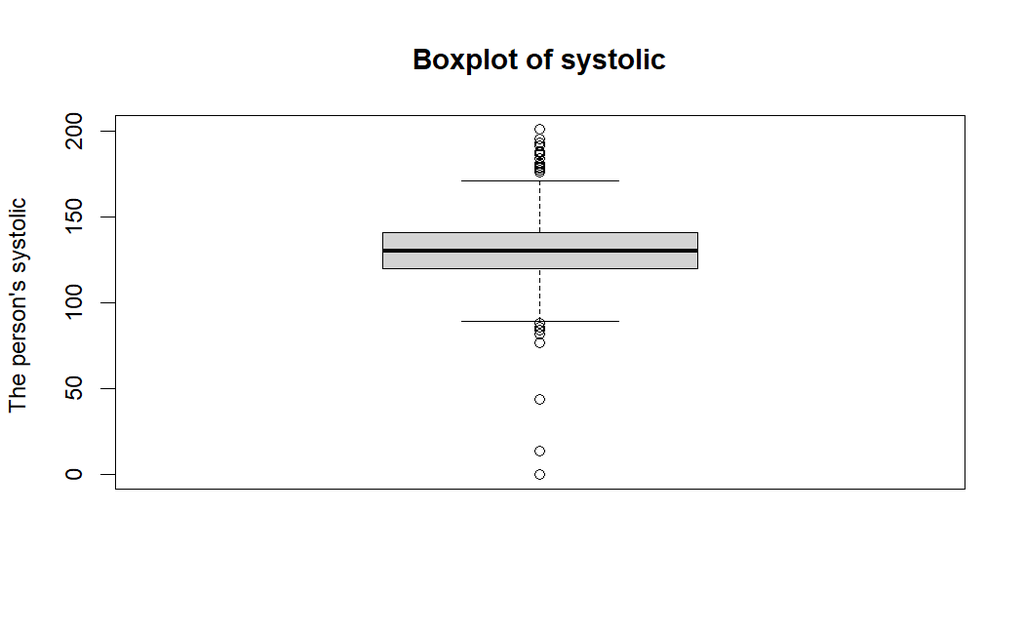

```r
#systolic box plot:
boxplot(dataset$systolic,
        ylab= "The person's systolic " ,
        main= "Boxplot of systolic")
```

The boxplot of gripForce (fingers flexibility tests) shows how the values in the dataset have been evenly distributed around the median value of 37.90, and, there some outliers that we will handle them

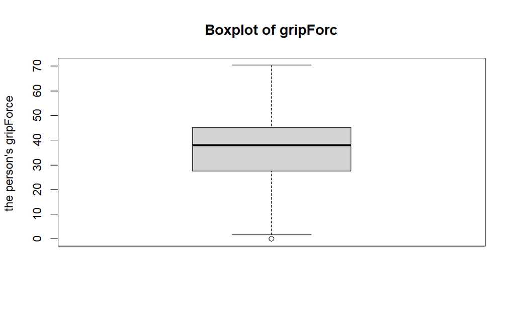

```r
#gripForce box plot:
boxplot(dataset$gripForc,
        ylab= "the person's gripForce " ,
        main= "Boxplot of gripForc")
```

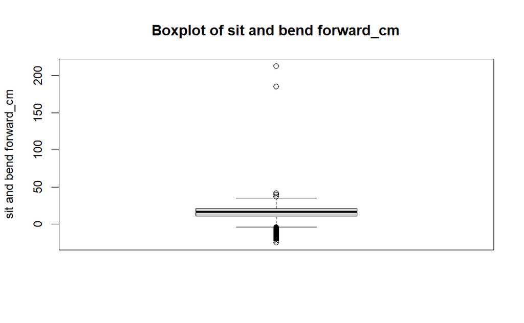

The boxplot of the “Test that measures the strength and endurance of the abdominals and hip-fle” shows how the values in the dataset have been evenly distributed around the median value of 41, and, there’s no outliers showing on boxplot.

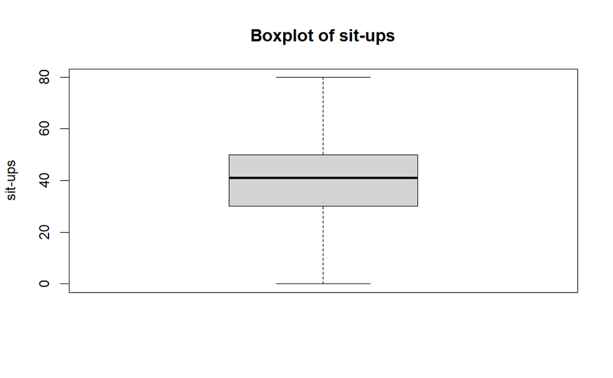

```r
#sit-ups counts_cm box plot:
boxplot(dataset$sit.ups.counts,
        ylab= "sit-ups" ,
        main= "Boxplot of sit-ups")
```

The boxplot of the “method of measuring how far a person can jump from a standing position to a landing position” shows how the values in the dataset have been evenly distributed around the median value of 193, and, there some minimum outliers that we will handle them in preprocessing step by deleting them.

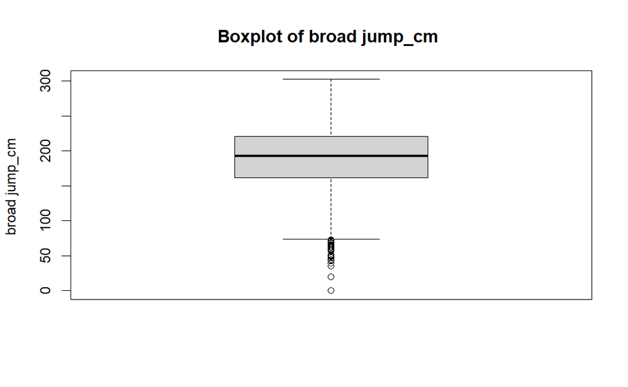

```r
#broad jump_cm box plot:
boxplot(dataset$broad.jump_cm,
        ylab= "broad jump_cm " ,
        main= "Boxplot of broad jump_cm ")
```

### Detect outlirs:

We noticed that “Age” has an Outlier that it’s not showing on the boxplot, where its an Outlier within the range. that’s mean those values are negatively affects on the dataset even though it is within range. So, we delete them

```r
#Detect outlir for 'age':
outAge = outlier(dataset$age, logical =TRUE)

#number of outliers:

sum(outAge)
```

```
[1] 215
```

```r
Find_outlier = which(outAge ==TRUE, arr.ind = TRUE)
outAge
```

```
   [1] FALSE FALSE FALSE FALSE FALSE FALSE FALSE FALSE FALSE FALSE FALSE FALSE FALSE FALSE FALSE FALSE FALSE FALSE FALSE FALSE FALSE FALSE FALSE FALSE FALSE
  [26] FALSE FALSE FALSE FALSE FALSE FALSE FALSE FALSE FALSE FALSE FALSE FALSE FALSE FALSE FALSE FALSE FALSE FALSE FALSE FALSE FALSE FALSE FALSE FALSE FALSE
  [51] FALSE FALSE FALSE FALSE FALSE FALSE FALSE FALSE FALSE FALSE FALSE FALSE FALSE FALSE FALSE FALSE FALSE FALSE FALSE FALSE FALSE FALSE FALSE FALSE FALSE
  [76] FALSE FALSE FALSE FALSE FALSE FALSE FALSE FALSE FALSE FALSE FALSE FALSE FALSE FALSE FALSE FALSE FALSE FALSE FALSE FALSE FALSE FALSE FALSE FALSE FALSE
 [101] FALSE FALSE FALSE FALSE FALSE FALSE FALSE FALSE FALSE FALSE FALSE FALSE FALSE FALSE FALSE FALSE FALSE FALSE FALSE FALSE FALSE FALSE FALSE FALSE FALSE
 [126] FALSE FALSE FALSE FALSE FALSE FALSE FALSE FALSE FALSE FALSE FALSE FALSE FALSE FALSE FALSE FALSE FALSE FALSE FALSE FALSE FALSE FALSE FALSE FALSE FALSE
 [151] FALSE FALSE FALSE FALSE FALSE FALSE FALSE FALSE FALSE FALSE FALSE FALSE FALSE FALSE FALSE FALSE FALSE FALSE FALSE FALSE FALSE FALSE FALSE FALSE FALSE
 [176] FALSE FALSE FALSE FALSE FALSE FALSE  TRUE FALSE FALSE FALSE FALSE FALSE FALSE FALSE FALSE FALSE FALSE FALSE FALSE FALSE FALSE FALSE FALSE FALSE FALSE
 [201] FALSE FALSE FALSE FALSE FALSE FALSE FALSE FALSE FALSE FALSE FALSE FALSE FALSE FALSE FALSE FALSE FALSE FALSE FALSE FALSE FALSE FALSE FALSE FALSE FALSE
 [226] FALSE FALSE FALSE FALSE FALSE FALSE FALSE FALSE FALSE FALSE FALSE FALSE FALSE FALSE FALSE FALSE FALSE FALSE FALSE FALSE FALSE FALSE FALSE FALSE FALSE
 [251] FALSE FALSE FALSE FALSE FALSE FALSE FALSE FALSE FALSE FALSE FALSE FALSE FALSE FALSE FALSE FALSE FALSE FALSE FALSE FALSE FALSE FALSE FALSE FALSE FALSE
 [276] FALSE FALSE FALSE FALSE FALSE FALSE FALSE FALSE FALSE FALSE FALSE FALSE FALSE FALSE FALSE FALSE FALSE FALSE FALSE FALSE FALSE FALSE FALSE FALSE FALSE
 [301] FALSE FALSE FALSE FALSE FALSE  TRUE FALSE  TRUE FALSE FALSE FALSE FALSE FALSE FALSE FALSE FALSE FALSE FALSE FALSE FALSE FALSE FALSE FALSE FALSE FALSE
 [326] FALSE FALSE FALSE FALSE FALSE FALSE FALSE FALSE FALSE FALSE FALSE FALSE FALSE FALSE FALSE FALSE FALSE  TRUE FALSE FALSE FALSE FALSE FALSE FALSE FALSE
 [351] FALSE FALSE FALSE FALSE FALSE FALSE FALSE FALSE FALSE FALSE FALSE FALSE FALSE FALSE FALSE FALSE FALSE FALSE FALSE FALSE FALSE FALSE FALSE FALSE FALSE
```

[output cut: 26 more lines]

```r
Find_outlier
```

```
  [1]   182   306   308   343   403   421   433   629   704   761   900   930   948  1061  1103  1122  1153  1199  1356  1485  1550  1635  1647  1661  1857
 [26]  1985  2008  2033  2085  2253  2307  2369  2375  2395  2402  2421  2533  2558  2587  2619  2647  2664  2769  2783  2881  2918  2988  3032  3050  3063
 [51]  3159  3228  3479  3484  3524  3545  3787  3792  3885  3941  3975  4067  4139  4163  4256  4297  4432  4441  4542  4553  4620  4636  4821  4828  4882
 [76]  4934  4946  4950  4999  5030  5085  5124  5125  5210  5216  5249  5288  5408  5427  5448  5473  5496  5546  5565  5635  5730  5826  5932  6008  6331
[101]  6348  6591  6618  6619  6706  6733  6781  6850  6996  7132  7134  7390  7394  7396  7512  7601  7624  7641  7644  7665  7682  7739  7864  7930  7943
[126]  7994  8007  8183  8187  8228  8268  8308  8344  8981  9026  9027  9044  9054  9067  9068  9091  9188  9300  9476  9553  9575  9684  9744  9753  9824
[151]  9828  9902  9973 10057 10129 10163 10181 10441 10535 10544 10741 10851 10883 10888 11055 11062 11099 11129 11130 11191 11238 11269 11332 11443 11677
[176] 11709 11749 11808 11839 11849 11894 11930 11983 12020 12033 12036 12069 12101 12117 12140 12153 12239 12254 12273 12278 12323 12486 12490 12499 12530
[201] 12544 12593 12599 12762 12828 13086 13088 13146 13188 13225 13295 13302 13373 13384 13391
```

```r
#Delete age outliers:
dataset= dataset[-Find_outlier,]
```

```r
#Detect outlir for 'height_cm':
outH = outlier(dataset$height_cm, logical =TRUE)
#number of outliers:
sum(outH)
```

```
[1] 1
```

```r
Find_outlier = which(outH ==TRUE, arr.ind = TRUE)
outH
```

```
   [1] FALSE FALSE FALSE FALSE FALSE FALSE FALSE FALSE FALSE FALSE FALSE FALSE FALSE FALSE FALSE FALSE FALSE FALSE FALSE FALSE FALSE FALSE FALSE FALSE FALSE
  [26] FALSE FALSE FALSE FALSE FALSE FALSE FALSE FALSE FALSE FALSE FALSE FALSE FALSE FALSE FALSE FALSE FALSE FALSE FALSE FALSE FALSE FALSE FALSE FALSE FALSE
  [51] FALSE FALSE FALSE FALSE FALSE FALSE FALSE FALSE FALSE FALSE FALSE FALSE FALSE FALSE FALSE FALSE FALSE FALSE FALSE FALSE FALSE FALSE FALSE FALSE FALSE
  [76] FALSE FALSE FALSE FALSE FALSE FALSE FALSE FALSE FALSE FALSE FALSE FALSE FALSE FALSE FALSE FALSE FALSE FALSE FALSE FALSE FALSE FALSE FALSE FALSE FALSE
 [101] FALSE FALSE FALSE FALSE FALSE FALSE FALSE FALSE FALSE FALSE FALSE FALSE FALSE FALSE FALSE FALSE FALSE FALSE FALSE FALSE FALSE FALSE FALSE FALSE FALSE
 [126] FALSE FALSE FALSE FALSE FALSE FALSE FALSE FALSE FALSE FALSE FALSE FALSE FALSE FALSE FALSE FALSE FALSE FALSE FALSE FALSE FALSE FALSE FALSE FALSE FALSE
 [151] FALSE FALSE FALSE FALSE FALSE FALSE FALSE FALSE FALSE FALSE FALSE FALSE FALSE FALSE FALSE FALSE FALSE FALSE FALSE FALSE FALSE FALSE FALSE FALSE FALSE
 [176] FALSE FALSE FALSE FALSE FALSE FALSE FALSE FALSE FALSE FALSE FALSE FALSE FALSE FALSE FALSE FALSE FALSE FALSE FALSE FALSE FALSE FALSE FALSE FALSE FALSE
 [201] FALSE FALSE FALSE FALSE FALSE FALSE FALSE FALSE FALSE FALSE FALSE FALSE FALSE FALSE FALSE FALSE FALSE FALSE FALSE FALSE FALSE FALSE FALSE FALSE FALSE
 [226] FALSE FALSE FALSE FALSE FALSE FALSE FALSE FALSE FALSE FALSE FALSE FALSE FALSE FALSE FALSE FALSE FALSE FALSE FALSE FALSE FALSE FALSE FALSE FALSE FALSE
 [251] FALSE FALSE FALSE FALSE FALSE FALSE FALSE FALSE FALSE FALSE FALSE FALSE FALSE FALSE FALSE FALSE FALSE FALSE FALSE FALSE FALSE FALSE FALSE FALSE FALSE
 [276] FALSE FALSE FALSE FALSE FALSE FALSE FALSE FALSE FALSE FALSE FALSE FALSE FALSE FALSE FALSE FALSE FALSE FALSE FALSE FALSE FALSE FALSE FALSE FALSE FALSE
 [301] FALSE FALSE FALSE FALSE FALSE FALSE FALSE FALSE FALSE FALSE FALSE FALSE FALSE FALSE FALSE FALSE FALSE FALSE FALSE FALSE FALSE FALSE FALSE FALSE FALSE
 [326] FALSE FALSE FALSE FALSE FALSE FALSE FALSE FALSE FALSE FALSE FALSE FALSE FALSE FALSE FALSE FALSE FALSE FALSE FALSE FALSE FALSE FALSE FALSE FALSE FALSE
 [351] FALSE FALSE FALSE FALSE FALSE FALSE FALSE FALSE FALSE FALSE FALSE FALSE FALSE FALSE FALSE FALSE FALSE FALSE FALSE FALSE FALSE FALSE FALSE FALSE FALSE
```

[output cut: 26 more lines]

```r
Find_outlier
```

```
[1] 8122
```

```r
#Delete height_cm outliers:
dataset= dataset[-Find_outlier,]
```

```r
#Detect outlir for 'weight_kg':
outW= outlier(dataset$weight_kg, logical =TRUE)
#number of outliers:
sum(outW)
```

```
[1] 1
```

```r
Find_outlier = which(outW ==TRUE, arr.ind = TRUE)
outW
```

```
   [1] FALSE FALSE FALSE FALSE FALSE FALSE FALSE FALSE FALSE FALSE FALSE FALSE FALSE FALSE FALSE FALSE FALSE FALSE FALSE FALSE FALSE FALSE FALSE FALSE FALSE
  [26] FALSE FALSE FALSE FALSE FALSE FALSE FALSE FALSE FALSE FALSE FALSE FALSE FALSE FALSE FALSE FALSE FALSE FALSE FALSE FALSE FALSE FALSE FALSE FALSE FALSE
  [51] FALSE FALSE FALSE FALSE FALSE FALSE FALSE FALSE FALSE FALSE FALSE FALSE FALSE FALSE FALSE FALSE FALSE FALSE FALSE FALSE FALSE FALSE FALSE FALSE FALSE
  [76] FALSE FALSE FALSE FALSE FALSE FALSE FALSE FALSE FALSE FALSE FALSE FALSE FALSE FALSE FALSE FALSE FALSE FALSE FALSE FALSE FALSE FALSE FALSE FALSE FALSE
 [101] FALSE FALSE FALSE FALSE FALSE FALSE FALSE FALSE FALSE FALSE FALSE FALSE FALSE FALSE FALSE FALSE FALSE FALSE FALSE FALSE FALSE FALSE FALSE FALSE FALSE
 [126] FALSE FALSE FALSE FALSE FALSE FALSE FALSE FALSE FALSE FALSE FALSE FALSE FALSE FALSE FALSE FALSE FALSE FALSE FALSE FALSE FALSE FALSE FALSE FALSE FALSE
 [151] FALSE FALSE FALSE FALSE FALSE FALSE FALSE FALSE FALSE FALSE FALSE FALSE FALSE FALSE FALSE FALSE FALSE FALSE FALSE FALSE FALSE FALSE FALSE FALSE FALSE
 [176] FALSE FALSE FALSE FALSE FALSE FALSE FALSE FALSE FALSE FALSE FALSE FALSE FALSE FALSE FALSE FALSE FALSE FALSE FALSE FALSE FALSE FALSE FALSE FALSE FALSE
 [201] FALSE FALSE FALSE FALSE FALSE FALSE FALSE FALSE FALSE FALSE FALSE FALSE FALSE FALSE FALSE FALSE FALSE FALSE FALSE FALSE FALSE FALSE FALSE FALSE FALSE
 [226] FALSE FALSE FALSE FALSE FALSE FALSE FALSE FALSE FALSE FALSE FALSE FALSE FALSE FALSE FALSE FALSE FALSE FALSE FALSE FALSE FALSE FALSE FALSE FALSE FALSE
 [251] FALSE FALSE FALSE FALSE FALSE FALSE FALSE FALSE FALSE FALSE FALSE FALSE FALSE FALSE FALSE FALSE FALSE FALSE FALSE FALSE FALSE FALSE FALSE FALSE FALSE
 [276] FALSE FALSE FALSE FALSE FALSE FALSE FALSE FALSE FALSE FALSE FALSE FALSE FALSE FALSE FALSE FALSE FALSE FALSE FALSE FALSE FALSE FALSE FALSE FALSE FALSE
 [301] FALSE FALSE FALSE FALSE FALSE FALSE FALSE FALSE FALSE FALSE FALSE FALSE FALSE FALSE FALSE FALSE FALSE FALSE FALSE FALSE FALSE FALSE FALSE FALSE FALSE
 [326] FALSE FALSE FALSE FALSE FALSE FALSE FALSE FALSE FALSE FALSE FALSE FALSE FALSE FALSE FALSE FALSE FALSE FALSE FALSE FALSE FALSE FALSE FALSE FALSE FALSE
 [351] FALSE FALSE FALSE FALSE FALSE FALSE FALSE FALSE FALSE FALSE FALSE FALSE FALSE FALSE FALSE FALSE FALSE FALSE FALSE FALSE FALSE FALSE FALSE FALSE FALSE
```

[output cut: 26 more lines]

```r
Find_outlier
```

```
[1] 10976
```

```r
#Delete weight_kg outliers:
dataset= dataset[-Find_outlier,]
```

```r
#Detect outlir for 'body.fat\_.':

outefat = outlier(dataset$body.fat_., logical =TRUE)
#number of outliers:
sum(outefat)
```

```
[1] 1
```

```r
Find_outlier = which(outefat ==TRUE, arr.ind = TRUE)
outefat
```

```
   [1] FALSE FALSE FALSE FALSE FALSE FALSE FALSE FALSE FALSE FALSE FALSE FALSE FALSE FALSE FALSE FALSE FALSE FALSE FALSE FALSE FALSE FALSE FALSE FALSE FALSE
  [26] FALSE FALSE FALSE FALSE FALSE FALSE FALSE FALSE FALSE FALSE FALSE FALSE FALSE FALSE FALSE FALSE FALSE FALSE FALSE FALSE FALSE FALSE FALSE FALSE FALSE
  [51] FALSE FALSE FALSE FALSE FALSE FALSE FALSE FALSE FALSE FALSE FALSE FALSE FALSE FALSE FALSE FALSE FALSE FALSE FALSE FALSE FALSE FALSE FALSE FALSE FALSE
  [76] FALSE FALSE FALSE FALSE FALSE FALSE FALSE FALSE FALSE FALSE FALSE FALSE FALSE FALSE FALSE FALSE FALSE FALSE FALSE FALSE FALSE FALSE FALSE FALSE FALSE
 [101] FALSE FALSE FALSE FALSE FALSE FALSE FALSE FALSE FALSE FALSE FALSE FALSE FALSE FALSE FALSE FALSE FALSE FALSE FALSE FALSE FALSE FALSE FALSE FALSE FALSE
 [126] FALSE FALSE FALSE FALSE FALSE FALSE FALSE FALSE FALSE FALSE FALSE FALSE FALSE FALSE FALSE FALSE FALSE FALSE FALSE FALSE FALSE FALSE FALSE FALSE FALSE
 [151] FALSE FALSE FALSE FALSE FALSE FALSE FALSE FALSE FALSE FALSE FALSE FALSE FALSE FALSE FALSE FALSE FALSE FALSE FALSE FALSE FALSE FALSE FALSE FALSE FALSE
 [176] FALSE FALSE FALSE FALSE FALSE FALSE FALSE FALSE FALSE FALSE FALSE FALSE FALSE FALSE FALSE FALSE FALSE FALSE FALSE FALSE FALSE FALSE FALSE FALSE FALSE
 [201] FALSE FALSE FALSE FALSE FALSE FALSE FALSE FALSE FALSE FALSE FALSE FALSE FALSE FALSE FALSE FALSE FALSE FALSE FALSE FALSE FALSE FALSE FALSE FALSE FALSE
 [226] FALSE FALSE FALSE FALSE FALSE FALSE FALSE FALSE FALSE FALSE FALSE FALSE FALSE FALSE FALSE FALSE FALSE FALSE FALSE FALSE FALSE FALSE FALSE FALSE FALSE
 [251] FALSE FALSE FALSE FALSE FALSE FALSE FALSE FALSE FALSE FALSE FALSE FALSE FALSE FALSE FALSE FALSE FALSE FALSE FALSE FALSE FALSE FALSE FALSE FALSE FALSE
 [276] FALSE FALSE FALSE FALSE FALSE FALSE FALSE FALSE FALSE FALSE FALSE FALSE FALSE FALSE FALSE FALSE FALSE FALSE FALSE FALSE FALSE FALSE FALSE FALSE FALSE
 [301] FALSE FALSE FALSE FALSE FALSE FALSE FALSE FALSE FALSE FALSE FALSE FALSE FALSE FALSE FALSE FALSE FALSE FALSE FALSE FALSE FALSE FALSE FALSE FALSE FALSE
 [326] FALSE FALSE FALSE FALSE FALSE FALSE FALSE FALSE FALSE FALSE FALSE FALSE FALSE FALSE FALSE FALSE FALSE FALSE FALSE FALSE FALSE FALSE FALSE FALSE FALSE
 [351] FALSE FALSE FALSE FALSE FALSE FALSE FALSE FALSE FALSE FALSE FALSE FALSE FALSE FALSE FALSE FALSE FALSE FALSE FALSE FALSE FALSE FALSE FALSE FALSE FALSE
```

[output cut: 26 more lines]

```r
Find_outlier
```

```
[1] 727
```

```r
#Delete body.fat outliers:
dataset= dataset[-Find_outlier,]
```

```r
#Detect outlir for 'systolic':
outesys = outlier(dataset$systolic, logical =TRUE)
#number of outliers:
sum(outesys)
```

```
[1] 1
```

```r
Find_outlier = which(outesys ==TRUE, arr.ind = TRUE)
outesys
```

```
   [1] FALSE FALSE FALSE FALSE FALSE FALSE FALSE FALSE FALSE FALSE FALSE FALSE FALSE FALSE FALSE FALSE FALSE FALSE FALSE FALSE FALSE FALSE FALSE FALSE FALSE
  [26] FALSE FALSE FALSE FALSE FALSE FALSE FALSE FALSE FALSE FALSE FALSE FALSE FALSE FALSE FALSE FALSE FALSE FALSE FALSE FALSE FALSE FALSE FALSE FALSE FALSE
  [51] FALSE FALSE FALSE FALSE FALSE FALSE FALSE FALSE FALSE FALSE FALSE FALSE FALSE FALSE FALSE FALSE FALSE FALSE FALSE FALSE FALSE FALSE FALSE FALSE FALSE
  [76] FALSE FALSE FALSE FALSE FALSE FALSE FALSE FALSE FALSE FALSE FALSE FALSE FALSE FALSE FALSE FALSE FALSE FALSE FALSE FALSE FALSE FALSE FALSE FALSE FALSE
 [101] FALSE FALSE FALSE FALSE FALSE FALSE FALSE FALSE FALSE FALSE FALSE FALSE FALSE FALSE FALSE FALSE FALSE FALSE FALSE FALSE FALSE FALSE FALSE FALSE FALSE
 [126] FALSE FALSE FALSE FALSE FALSE FALSE FALSE FALSE FALSE FALSE FALSE FALSE FALSE FALSE FALSE FALSE FALSE FALSE FALSE FALSE FALSE FALSE FALSE FALSE FALSE
 [151] FALSE FALSE FALSE FALSE FALSE FALSE FALSE FALSE FALSE FALSE FALSE FALSE FALSE FALSE FALSE FALSE FALSE FALSE FALSE FALSE FALSE FALSE FALSE FALSE FALSE
 [176] FALSE FALSE FALSE FALSE FALSE FALSE FALSE FALSE FALSE FALSE FALSE FALSE FALSE FALSE FALSE FALSE FALSE FALSE FALSE FALSE FALSE FALSE FALSE FALSE FALSE
 [201] FALSE FALSE FALSE FALSE FALSE FALSE FALSE FALSE FALSE FALSE FALSE FALSE FALSE FALSE FALSE FALSE FALSE FALSE FALSE FALSE FALSE FALSE FALSE FALSE FALSE
 [226] FALSE FALSE FALSE FALSE FALSE FALSE FALSE FALSE FALSE FALSE FALSE FALSE FALSE FALSE FALSE FALSE FALSE FALSE FALSE FALSE FALSE FALSE FALSE FALSE FALSE
 [251] FALSE FALSE FALSE FALSE FALSE FALSE FALSE FALSE FALSE FALSE FALSE FALSE FALSE FALSE FALSE FALSE FALSE FALSE FALSE FALSE FALSE FALSE FALSE FALSE FALSE
 [276] FALSE FALSE FALSE FALSE FALSE FALSE FALSE FALSE FALSE FALSE FALSE FALSE FALSE FALSE FALSE FALSE FALSE FALSE FALSE FALSE FALSE FALSE FALSE FALSE FALSE
 [301] FALSE FALSE FALSE FALSE FALSE FALSE FALSE FALSE FALSE FALSE FALSE FALSE FALSE FALSE FALSE FALSE FALSE FALSE FALSE FALSE FALSE FALSE FALSE FALSE FALSE
 [326] FALSE FALSE FALSE FALSE FALSE FALSE FALSE FALSE FALSE FALSE FALSE FALSE FALSE FALSE FALSE FALSE FALSE FALSE FALSE FALSE FALSE FALSE FALSE FALSE FALSE
 [351] FALSE FALSE FALSE FALSE FALSE FALSE FALSE FALSE FALSE FALSE FALSE FALSE FALSE FALSE FALSE FALSE FALSE FALSE FALSE FALSE FALSE FALSE FALSE FALSE FALSE
```

[output cut: 26 more lines]

```r
Find_outlier
```

```
[1] 10463
```

```r
#Delete systolic outliers:
dataset= dataset[-Find_outlier,]
```

As we saw in boxplot there was only one outlier. However, here we detected 3 values, where 2 are within the range but we will take it as an outliers sinces those values may have a negatively affects on the dataset specifically on “class” attribute.

```r
#Detect outlir for 'gripForce':
outegrip = outlier(dataset$gripForce, logical =TRUE)
#number of outliers:
sum(outegrip)
```

```
[1] 3
```

```r
Find_outlier = which(outegrip ==TRUE, arr.ind = TRUE)
outegrip
```

```
   [1] FALSE FALSE FALSE FALSE FALSE FALSE FALSE FALSE FALSE FALSE FALSE FALSE FALSE FALSE FALSE FALSE FALSE FALSE FALSE FALSE FALSE FALSE FALSE FALSE FALSE
  [26] FALSE FALSE FALSE FALSE FALSE FALSE FALSE FALSE FALSE FALSE FALSE FALSE FALSE FALSE FALSE FALSE FALSE FALSE FALSE FALSE FALSE FALSE FALSE FALSE FALSE
  [51] FALSE FALSE FALSE FALSE FALSE FALSE FALSE FALSE FALSE FALSE FALSE FALSE FALSE FALSE FALSE FALSE FALSE FALSE FALSE FALSE FALSE FALSE FALSE FALSE FALSE
  [76] FALSE FALSE FALSE FALSE FALSE FALSE FALSE FALSE FALSE FALSE FALSE FALSE FALSE FALSE FALSE FALSE FALSE FALSE FALSE FALSE FALSE FALSE FALSE FALSE FALSE
 [101] FALSE FALSE FALSE FALSE FALSE FALSE FALSE FALSE FALSE FALSE FALSE FALSE FALSE FALSE FALSE FALSE FALSE FALSE FALSE FALSE FALSE FALSE FALSE FALSE FALSE
 [126] FALSE FALSE FALSE FALSE FALSE FALSE FALSE FALSE FALSE FALSE FALSE FALSE FALSE FALSE FALSE FALSE FALSE FALSE FALSE FALSE FALSE FALSE FALSE FALSE FALSE
 [151] FALSE FALSE FALSE FALSE FALSE FALSE FALSE FALSE FALSE FALSE FALSE FALSE FALSE FALSE FALSE FALSE FALSE FALSE FALSE FALSE FALSE FALSE FALSE FALSE FALSE
 [176] FALSE FALSE FALSE FALSE FALSE FALSE FALSE FALSE FALSE FALSE FALSE FALSE FALSE FALSE FALSE FALSE FALSE FALSE FALSE FALSE FALSE FALSE FALSE FALSE FALSE
 [201] FALSE FALSE FALSE FALSE FALSE FALSE FALSE FALSE FALSE FALSE FALSE FALSE FALSE FALSE FALSE FALSE FALSE FALSE FALSE FALSE FALSE FALSE FALSE FALSE FALSE
 [226] FALSE FALSE FALSE FALSE FALSE FALSE FALSE FALSE FALSE FALSE FALSE FALSE FALSE FALSE FALSE FALSE FALSE FALSE FALSE FALSE FALSE FALSE FALSE FALSE FALSE
 [251] FALSE FALSE FALSE FALSE FALSE FALSE FALSE FALSE FALSE FALSE FALSE FALSE FALSE FALSE FALSE FALSE FALSE FALSE FALSE FALSE FALSE FALSE FALSE FALSE FALSE
 [276] FALSE FALSE FALSE FALSE FALSE FALSE FALSE FALSE FALSE FALSE FALSE FALSE FALSE FALSE FALSE FALSE FALSE FALSE FALSE FALSE FALSE FALSE FALSE FALSE FALSE
 [301] FALSE FALSE FALSE FALSE FALSE FALSE FALSE FALSE FALSE FALSE FALSE FALSE FALSE FALSE FALSE FALSE FALSE FALSE FALSE FALSE FALSE FALSE FALSE FALSE FALSE
 [326] FALSE FALSE FALSE FALSE FALSE FALSE FALSE FALSE FALSE FALSE FALSE FALSE FALSE FALSE FALSE FALSE FALSE FALSE FALSE FALSE FALSE FALSE FALSE FALSE FALSE
 [351] FALSE FALSE FALSE FALSE FALSE FALSE FALSE FALSE FALSE FALSE FALSE FALSE FALSE FALSE FALSE FALSE FALSE FALSE FALSE FALSE FALSE FALSE FALSE FALSE FALSE
```

[output cut: 26 more lines]

```r
Find_outlier
```

```
[1] 8428 9341 9618
```

```r
#Delete gripForce  outliers:
dataset= dataset[-Find_outlier,]
```

```r
#Detect outlir for 'sit.and.bend.forward_cm':
outesit = outlier(dataset$sit.and.bend.forward_cm, logical =TRUE)
#number of outliers:
sum(outesit)
```

```
[1] 1
```

```r
Find_outlier = which(outesit ==TRUE, arr.ind = TRUE)
outesit
```

```
   [1] FALSE FALSE FALSE FALSE FALSE FALSE FALSE FALSE FALSE FALSE FALSE FALSE FALSE FALSE FALSE FALSE FALSE FALSE FALSE FALSE FALSE FALSE FALSE FALSE FALSE
  [26] FALSE FALSE FALSE FALSE FALSE FALSE FALSE FALSE FALSE FALSE FALSE FALSE FALSE FALSE FALSE FALSE FALSE FALSE FALSE FALSE FALSE FALSE FALSE FALSE FALSE
  [51] FALSE FALSE FALSE FALSE FALSE FALSE FALSE FALSE FALSE FALSE FALSE FALSE FALSE FALSE FALSE FALSE FALSE FALSE FALSE FALSE FALSE FALSE FALSE FALSE FALSE
  [76] FALSE FALSE FALSE FALSE FALSE FALSE FALSE FALSE FALSE FALSE FALSE FALSE FALSE FALSE FALSE FALSE FALSE FALSE FALSE FALSE FALSE FALSE FALSE FALSE FALSE
 [101] FALSE FALSE FALSE FALSE FALSE FALSE FALSE FALSE FALSE FALSE FALSE FALSE FALSE FALSE FALSE FALSE FALSE FALSE FALSE FALSE FALSE FALSE FALSE FALSE FALSE
 [126] FALSE FALSE FALSE FALSE FALSE FALSE FALSE FALSE FALSE FALSE FALSE FALSE FALSE FALSE FALSE FALSE FALSE FALSE FALSE FALSE FALSE FALSE FALSE FALSE FALSE
 [151] FALSE FALSE FALSE FALSE FALSE FALSE FALSE FALSE FALSE FALSE FALSE FALSE FALSE FALSE FALSE FALSE FALSE FALSE FALSE FALSE FALSE FALSE FALSE FALSE FALSE
 [176] FALSE FALSE FALSE FALSE FALSE FALSE FALSE FALSE FALSE FALSE FALSE FALSE FALSE FALSE FALSE FALSE FALSE FALSE FALSE FALSE FALSE FALSE FALSE FALSE FALSE
 [201] FALSE FALSE FALSE FALSE FALSE FALSE FALSE FALSE FALSE FALSE FALSE FALSE FALSE FALSE FALSE FALSE FALSE FALSE FALSE FALSE FALSE FALSE FALSE FALSE FALSE
 [226] FALSE FALSE FALSE FALSE FALSE FALSE FALSE FALSE FALSE FALSE FALSE FALSE FALSE FALSE FALSE FALSE FALSE FALSE FALSE FALSE FALSE FALSE FALSE FALSE FALSE
 [251] FALSE FALSE FALSE FALSE FALSE FALSE FALSE FALSE FALSE FALSE FALSE FALSE FALSE FALSE FALSE FALSE FALSE FALSE FALSE FALSE FALSE FALSE FALSE FALSE FALSE
 [276] FALSE FALSE FALSE FALSE FALSE FALSE FALSE FALSE FALSE FALSE FALSE FALSE FALSE FALSE FALSE FALSE FALSE FALSE FALSE FALSE FALSE FALSE FALSE FALSE FALSE
 [301] FALSE FALSE FALSE FALSE FALSE FALSE FALSE FALSE FALSE FALSE FALSE FALSE FALSE FALSE FALSE FALSE FALSE FALSE FALSE FALSE FALSE FALSE FALSE FALSE FALSE
 [326] FALSE FALSE FALSE FALSE FALSE FALSE FALSE FALSE FALSE FALSE FALSE FALSE FALSE FALSE FALSE FALSE FALSE FALSE FALSE FALSE FALSE FALSE FALSE FALSE FALSE
 [351] FALSE FALSE FALSE FALSE FALSE FALSE FALSE FALSE FALSE FALSE FALSE FALSE FALSE FALSE FALSE FALSE FALSE FALSE FALSE FALSE FALSE FALSE FALSE FALSE FALSE
```

[output cut: 26 more lines]

```r
Find_outlier
```

```
[1] 2616
```

```r
#Delete sit.and.bend.forward_cm outliers:
dataset= dataset[-Find_outlier,]
```

we notic some outliers within the range and we will deleting them as an outliers since it’s effects other attributes negatively.

```r
#Detect outlir for 'sit.up.count':
outesitup = outlier(dataset$sit.ups.counts, logical =TRUE)
#number of outliers:
sum(outesitup)
```

```
[1] 113
```

```r
Find_outlier = which(outesitup ==TRUE, arr.ind = TRUE)
outesitup
```

```
   [1] FALSE FALSE FALSE FALSE FALSE FALSE FALSE FALSE FALSE FALSE FALSE  TRUE FALSE FALSE FALSE FALSE FALSE FALSE FALSE FALSE FALSE FALSE FALSE FALSE FALSE
  [26] FALSE FALSE FALSE FALSE FALSE FALSE FALSE FALSE FALSE FALSE FALSE FALSE FALSE FALSE FALSE FALSE FALSE FALSE FALSE FALSE FALSE FALSE FALSE FALSE FALSE
  [51] FALSE FALSE FALSE FALSE FALSE FALSE FALSE FALSE FALSE FALSE FALSE FALSE FALSE FALSE FALSE FALSE FALSE FALSE FALSE FALSE FALSE FALSE FALSE FALSE FALSE
  [76] FALSE FALSE FALSE FALSE FALSE FALSE FALSE FALSE FALSE FALSE FALSE FALSE FALSE FALSE FALSE FALSE FALSE FALSE FALSE FALSE FALSE FALSE FALSE FALSE FALSE
 [101] FALSE FALSE FALSE FALSE FALSE FALSE FALSE FALSE FALSE FALSE FALSE FALSE FALSE FALSE FALSE FALSE FALSE FALSE FALSE FALSE FALSE FALSE FALSE FALSE FALSE
 [126] FALSE FALSE FALSE FALSE FALSE FALSE FALSE FALSE FALSE FALSE FALSE  TRUE FALSE FALSE FALSE FALSE FALSE FALSE FALSE FALSE FALSE FALSE FALSE FALSE FALSE
 [151] FALSE FALSE FALSE FALSE FALSE FALSE FALSE FALSE FALSE FALSE FALSE FALSE FALSE FALSE FALSE FALSE FALSE FALSE FALSE FALSE FALSE FALSE FALSE FALSE FALSE
 [176] FALSE FALSE FALSE FALSE FALSE FALSE FALSE FALSE FALSE FALSE FALSE FALSE FALSE  TRUE FALSE FALSE FALSE FALSE FALSE FALSE FALSE FALSE FALSE FALSE FALSE
 [201] FALSE FALSE FALSE FALSE FALSE FALSE FALSE FALSE FALSE FALSE FALSE FALSE FALSE FALSE FALSE FALSE FALSE FALSE FALSE FALSE FALSE FALSE FALSE FALSE FALSE
 [226] FALSE FALSE FALSE FALSE FALSE FALSE FALSE FALSE FALSE FALSE FALSE FALSE FALSE FALSE FALSE FALSE FALSE FALSE FALSE FALSE FALSE FALSE FALSE FALSE FALSE
 [251] FALSE FALSE FALSE FALSE FALSE FALSE FALSE FALSE FALSE FALSE FALSE FALSE FALSE FALSE FALSE FALSE FALSE FALSE FALSE FALSE FALSE FALSE FALSE FALSE FALSE
 [276] FALSE FALSE FALSE FALSE FALSE FALSE FALSE FALSE FALSE FALSE FALSE FALSE FALSE FALSE FALSE FALSE FALSE FALSE FALSE FALSE FALSE FALSE FALSE FALSE FALSE
 [301] FALSE FALSE FALSE FALSE FALSE FALSE FALSE FALSE FALSE FALSE FALSE FALSE FALSE FALSE FALSE FALSE FALSE FALSE FALSE FALSE FALSE FALSE FALSE FALSE FALSE
 [326] FALSE FALSE FALSE FALSE FALSE FALSE FALSE FALSE FALSE FALSE FALSE FALSE FALSE FALSE FALSE FALSE FALSE FALSE FALSE FALSE FALSE FALSE FALSE FALSE FALSE
 [351] FALSE FALSE FALSE FALSE FALSE FALSE FALSE FALSE FALSE FALSE FALSE FALSE FALSE FALSE FALSE FALSE FALSE FALSE FALSE FALSE FALSE FALSE FALSE FALSE FALSE
```

[output cut: 26 more lines]

```r
Find_outlier
```

```
  [1]    12   137   189   401   493   531   673   704  1003  1674  1715  1835  1894  2031  2136  2294  2391  2394  2500  2536  2557  2567  2743  2750  2832
 [26]  2935  3036  3115  3194  3374  3422  3827  3832  4303  4304  4318  4380  4382  4411  4494  4809  4824  4866  5071  5312  5345  5475  5486  5520  5539
 [51]  5840  5942  5957  6275  6278  6372  6384  6481  6490  7238  7267  7297  7302  7315  7449  7771  7828  7877  7938  7978  7996  8097  8359  8416  8463
 [76]  8617  8630  8753  8902  9003  9034  9513  9644  9720  9828  9973 10073 10213 10233 10268 10443 10483 10534 10601 10798 10828 10875 10896 11110 11265
[101] 11365 11421 11515 11518 11898 11967 11995 12035 12046 12148 12420 12467 12514
```

```r
#Delete age outliers:
dataset= dataset[-Find_outlier,]
```

```r
#Detect outlir for 'broad.jump_cm':

Outjump = outlier(dataset$broad.jump_cm, logical =TRUE)
sum(Outjump)
```

```
[1] 5
```

```r
Find_outlier = which(Outjump ==TRUE, arr.ind = TRUE)
Outjump
```

```
   [1] FALSE FALSE FALSE FALSE FALSE FALSE FALSE FALSE FALSE FALSE FALSE FALSE FALSE FALSE FALSE FALSE FALSE FALSE FALSE FALSE FALSE FALSE FALSE FALSE FALSE
  [26] FALSE FALSE FALSE FALSE FALSE FALSE FALSE FALSE FALSE FALSE FALSE FALSE FALSE FALSE FALSE FALSE FALSE FALSE FALSE FALSE FALSE FALSE FALSE FALSE FALSE
  [51] FALSE FALSE FALSE FALSE FALSE FALSE FALSE FALSE FALSE FALSE FALSE FALSE FALSE FALSE FALSE FALSE FALSE FALSE FALSE FALSE FALSE FALSE FALSE FALSE FALSE
  [76] FALSE FALSE FALSE FALSE FALSE FALSE FALSE FALSE FALSE FALSE FALSE FALSE FALSE FALSE FALSE FALSE FALSE FALSE FALSE FALSE FALSE FALSE FALSE FALSE FALSE
 [101] FALSE FALSE FALSE FALSE FALSE FALSE FALSE FALSE FALSE FALSE FALSE FALSE FALSE FALSE FALSE FALSE FALSE FALSE FALSE FALSE FALSE FALSE FALSE FALSE FALSE
 [126] FALSE FALSE FALSE FALSE FALSE FALSE FALSE FALSE FALSE FALSE FALSE FALSE FALSE FALSE FALSE FALSE FALSE FALSE FALSE FALSE FALSE FALSE FALSE FALSE FALSE
 [151] FALSE FALSE FALSE FALSE FALSE FALSE FALSE FALSE FALSE FALSE FALSE FALSE FALSE FALSE FALSE FALSE FALSE FALSE FALSE FALSE FALSE FALSE FALSE FALSE FALSE
 [176] FALSE FALSE FALSE FALSE FALSE FALSE FALSE FALSE FALSE FALSE FALSE FALSE FALSE FALSE FALSE FALSE FALSE FALSE FALSE FALSE FALSE FALSE FALSE FALSE FALSE
 [201] FALSE FALSE FALSE FALSE FALSE FALSE FALSE FALSE FALSE FALSE FALSE FALSE FALSE FALSE FALSE FALSE FALSE FALSE FALSE FALSE FALSE FALSE FALSE FALSE FALSE
 [226] FALSE FALSE FALSE FALSE FALSE FALSE FALSE FALSE FALSE FALSE FALSE FALSE FALSE FALSE FALSE FALSE FALSE FALSE FALSE FALSE FALSE FALSE FALSE FALSE FALSE
 [251] FALSE FALSE FALSE FALSE FALSE FALSE FALSE FALSE FALSE FALSE FALSE FALSE FALSE FALSE FALSE FALSE FALSE FALSE FALSE FALSE FALSE FALSE FALSE FALSE FALSE
 [276] FALSE FALSE FALSE FALSE FALSE FALSE FALSE FALSE FALSE FALSE FALSE FALSE FALSE FALSE FALSE FALSE FALSE FALSE FALSE FALSE FALSE FALSE FALSE FALSE FALSE
 [301] FALSE FALSE FALSE FALSE FALSE FALSE FALSE FALSE FALSE FALSE FALSE FALSE FALSE FALSE FALSE FALSE FALSE FALSE FALSE FALSE FALSE FALSE FALSE FALSE FALSE
 [326] FALSE FALSE FALSE FALSE FALSE FALSE FALSE FALSE FALSE FALSE FALSE FALSE FALSE FALSE FALSE FALSE FALSE FALSE FALSE FALSE FALSE FALSE FALSE FALSE FALSE
 [351] FALSE FALSE FALSE FALSE FALSE FALSE FALSE FALSE FALSE FALSE FALSE FALSE FALSE FALSE FALSE FALSE FALSE FALSE FALSE FALSE FALSE FALSE FALSE FALSE FALSE
```

[output cut: 26 more lines]

```r
Find_outlier
```

```
[1]  474 4643 7194 7534 7752
```

```r
dataset= dataset[-Find_outlier,]
```

### Check rows and columns after deletion the outliers:

To make sure that the deletion was successful, we searched for the number of rows.

```r
#check after deleting
#Number of rows and column
nrow(dataset)
```

```
[1] 13051
```

```r
ncol(dataset)
```

```
[1] 12
```

We noticed a decrease in the number of rows, which means that deletion the outliers was successful.

### Normalizetion:

In order to ensure comparability across individuals and eliminate biases resulting from differences in measurement units or scales, we have decided to normalize the following attributes: height (in centimeters), weight (in kilograms), body fat percentage, diastolic, systolic, grip force, sit and bend forward distance (in centimeters), sit-ups count, and broad jump distance (in centimeters).

```r
View(dataset)
dataset [,3:4:5:6:7:8:9:11]=scale(dataset [,3:4:5:6:7:8:9:11])
```

```r
print(dataset)
```

|  | age | gender | height_cm | weight_kg | body.fat_. | diastolic | systolic | gripForce | sit.and.bend.forward_cm | sit.ups.counts | broad.jump_cm | class |
| --- | --- | --- | --- | --- | --- | --- | --- | --- | --- | --- | --- | --- |
| 1 | 27 | M | 0.424707783 | 0.644088714 | -0.246149981 | 0.11189173 | -0.01040515 | 1.678254508 | 0.381306676 | 1.43031832 | 0.657611752 | C |
| 2 | 25 | M | -0.451146412 | -0.984206785 | -1.032669481 | -0.16805746 | -0.28392871 | -0.075335666 | 0.127080149 | 0.91982642 | 0.969624897 | A |
| 3 | 31 | M | 1.300561978 | 0.875266470 | -0.414689874 | 1.23168848 | 1.49397443 | 0.720889062 | -0.393478932 | 0.62811676 | -0.278427683 | C |
| 4 | 32 | M | 0.688663841 | 0.297322080 | -0.653454722 | -0.26137386 | 1.15206998 | 0.398607624 | -0.006086128 | 0.91982642 | 0.709613943 | B |
| 5 | 28 | M | 0.604677823 | 0.012537888 | -0.836039606 | -0.82127223 | -0.21554782 | 0.597663806 | 1.434530862 | 0.33640710 | 0.657611752 | B |
| 6 | 36 | F | -0.403154402 | -1.017710808 | -0.147835043 | -1.38117061 | -0.76259494 | -1.269672759 | 0.696063329 | -0.97628635 | -1.006458355 | B |
| 7 | 42 | F | -0.511136426 | -0.322502338 | 1.284754048 | -0.63463944 | 0.33149930 | -1.373940282 | -1.749353745 | -1.63263308 | -1.188466022 | D |
| 8 | 33 | M | 0.736655852 | 0.808258425 | 1.944868629 | 0.48515731 | 0.46826108 | 0.825156585 | -0.357160856 | 0.11762486 | 1.099630374 | B |
| 9 | 54 | M | -0.235182364 | -0.004214124 | 0.638684458 | 0.57847371 | 2.38292601 | 0.303818966 | 0.405518726 | -0.46579445 | -1.136463832 | C |
| 10 | 28 | M | 1.948454122 | 1.428082843 | -1.215254366 | 0.20520812 | 1.76749799 | 1.962620483 | -0.381372906 | 1.06568125 | 0.553607370 | B |

[output cut: 990 more lines]

### Discretization :

```r
# Define bins for discretization
dataset$age=cut(dataset$age, breaks = seq(21,64, by=14), right=FALSE)
```

```r
print(dataset)
```

|  | age | gender | height_cm | weight_kg | body.fat_. | diastolic | systolic | gripForce | sit.and.bend.forward_cm | sit.ups.counts | broad.jump_cm | class |
| --- | --- | --- | --- | --- | --- | --- | --- | --- | --- | --- | --- | --- |
| 1 | [21,35) | M | 0.424707783 | 0.644088714 | -0.246149981 | 0.11189173 | -0.01040515 | 1.678254508 | 0.381306676 | 1.43031832 | 0.657611752 | C |
| 2 | [21,35) | M | -0.451146412 | -0.984206785 | -1.032669481 | -0.16805746 | -0.28392871 | -0.075335666 | 0.127080149 | 0.91982642 | 0.969624897 | A |
| 3 | [21,35) | M | 1.300561978 | 0.875266470 | -0.414689874 | 1.23168848 | 1.49397443 | 0.720889062 | -0.393478932 | 0.62811676 | -0.278427683 | C |
| 4 | [21,35) | M | 0.688663841 | 0.297322080 | -0.653454722 | -0.26137386 | 1.15206998 | 0.398607624 | -0.006086128 | 0.91982642 | 0.709613943 | B |
| 5 | [21,35) | M | 0.604677823 | 0.012537888 | -0.836039606 | -0.82127223 | -0.21554782 | 0.597663806 | 1.434530862 | 0.33640710 | 0.657611752 | B |
| 6 | [35,49) | F | -0.403154402 | -1.017710808 | -0.147835043 | -1.38117061 | -0.76259494 | -1.269672759 | 0.696063329 | -0.97628635 | -1.006458355 | B |
| 7 | [35,49) | F | -0.511136426 | -0.322502338 | 1.284754048 | -0.63463944 | 0.33149930 | -1.373940282 | -1.749353745 | -1.63263308 | -1.188466022 | D |
| 8 | [21,35) | M | 0.736655852 | 0.808258425 | 1.944868629 | 0.48515731 | 0.46826108 | 0.825156585 | -0.357160856 | 0.11762486 | 1.099630374 | B |
| 9 | [49,63) | M | -0.235182364 | -0.004214124 | 0.638684458 | 0.57847371 | 2.38292601 | 0.303818966 | 0.405518726 | -0.46579445 | -1.136463832 | C |
| 10 | [21,35) | M | 1.948454122 | 1.428082843 | -1.215254366 | 0.20520812 | 1.76749799 | 1.962620483 | -0.381372906 | 1.06568125 | 0.553607370 | B |

[output cut: 990 more lines]

### Feature Selection :

Based on the dataset and the graphs we did earlier, there are several justifications for not performing feature selection:

#### 1. Dimensionality:

The number of attributes (12) is not excessively high, and it is within a manageable range for modeling and analysis.

#### 2.Correlation Assessment:

just because some graphs indicate a lack of correlation between certain attributes, it doesn’t imply that those attributes hold no value or provide no assistance in enhancing individual body performance. It is important to recognize the interplay between these attributes and their impact on body performance. Consequently, removing any of these attributes may result in loss of valuable information.

#### 3. Interpretability:

By considering all the attributes, you can gain a deeper understanding of the relationships between different variables, and allows for a more comprehensive analysis providing more meaningful insights.

While feature selection can be beneficial in certain situations, in the case of analyzing body performance for individuals, it is important to consider all attributes without performing feature selection.